# example workflow

Denis Abu Sammour

This notebook is used as blueprint for the shiny app development and dedicated vignettes.

## Accompanying data

For more info on how to properly include data into packages check [this page](https://r-pkgs.org/data.html).

**data** subdirectroy contains a pre-processed and analysis-ready RData file, containing everything needed to run an example or web-hosted shiny app. This will be included on the Github (not Git-synced).

**inst/extdata/** subdirectroy contains: (this will be part of the package but not synced by Git)  
* two txt file holding the url of the imzml (and ibd) in metaspace.  
* one tsv file containing one single continuous (full) spectrum (used for the accompanying example data).  
* one tsv file cotaning filtered swiss lipids database (used internally).  
* one csv file containing metaspace annotations for the example datase (used for the accompanying example data).

**data-external** subdirectroy contains: (this is only for development, not Git-synced and will be removed later)  
* two files; imzML and ibd, processed examplary MSI data.

**data-shinyWebHosted** subdirectroy is meant to contain processed ready-to-analyze data preferrably in .RData envirobnment type. This would ideally work with a web-hosted shiny app and will load RData on start. Please check [this page](https://shiny.rstudio.com/articles/persistent-data-storage.html) and let me know if this is actually an option. If they do not allow for data hosting we could always fetch the Github::moleculaR/data/RData file by downloading it and loading it into the session.

## Package-app inputs/outputs

**[GUI Inputs]**  
**imzmlFile** string-browse, path to a single centroided (i.e. processed) imzML file.  
**spectrFile** string-browse, path to a single tsv file contianing a full continuous spectrum.  
*single analyte case*  
**queryMass** numeric-insert, m/z value. **probMapMethod** method used to generate the molecular probability map method.  
*collective projections case*  
**mtspc** string-browse, path to metaspace annotation file (.csv).  
**lipidSpecies** string-dropdown, values = `searchList$allClasses`

**[GUI Outputs]**  
**plot** fwhm as a function of m/z, generated after loading the single spectrum.  
*single analyte case* **image** ion image of the `queryMass`.  
**image** molecular probability map of the `queryMass`.

*collective projections case - if metaspace annotation file is not supplied*  
**image** collective probability map of all instances of the chosen `lipidSpecies`.

*collective projections case - if metaspace annotation file is provided*  
**image** collective probability map of confirmed instances of the chosen `lipidSpecies`.  
**console output** confirmed identifications.

## Workflow for package-app

### Load data

```r
library(moleculaR)
######################
#### local input #####
######################

#// MSI data - either load a local file
imzmlFile         = "pathToFile.imzML"                # <-- browse input-selected locally i.e. file will be
                                                       # uploaded to the temp dir of R.

imzmlFile         = file.path(getwd(), "data-external", "pos-XIII-82492-msi.imzML") # temporary, just to test this nb

#// read the file into R
msData            = readCentrData(path = imzmlFile)    # would be nice to console-notify when done reading


#// single spectrum -  load a local tsv file
spectrFile        = "pathToFile.tsv"                  # <-- browse input-selected locally i.e. file will be
                                                       # uploaded to the temp dir of R.

spectrFile        = system.file("extdata", "pos-XIII-82492-singleSpectrum.tsv", package = "moleculaR", mustWork = TRUE)# temporary
msSpectr          = readSingleSpect(spectrFile)


#// load the processed swisslipids db internally
pathTosldb        = system.file("extdata", "swisslipids-speciesOnly-sep2020.tsv", package = "moleculaR", mustWork = TRUE)
sldb              = loadSwissDB(pathTosldb)


#// load the metaspace annotations file - supplied by user
pathToMtspc       = "pathToFile.csv"                  # <-- browse input-selected locally
pathToMtspc        = system.file("extdata", "metaspace_annotations.csv", package = "moleculaR", mustWork = TRUE) # temporary
mtspc             = read.csv(file = pathToMtspc, skip = 2,header = TRUE, colClasses = "character")
```

### preprocessing of MS data

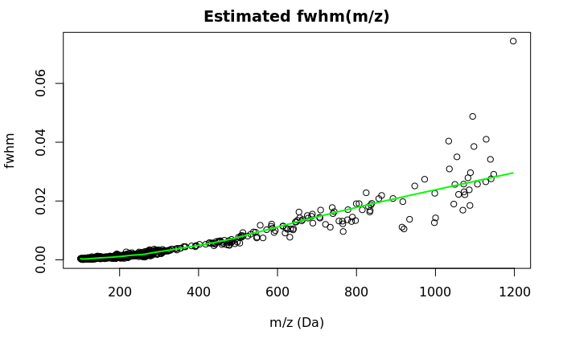

```r
#// estimate fwhm from msSpectr ----
fwhmFun           = estimateFwhm(s = msSpectr, plot = TRUE) # <-- this should be run directly after the spectrFile is
```

```r
                                                            # uploaded, a plot is generated


# bin peaks
# -- notify at start  --#
msData            =  MALDIquant::binPeaks(msData,
                                           tolerance = fwhmFun(400)/400, #focusing on lipids
                                           method = "relaxed")
# -- notify when done --#


# filter out peaks which occur in less than 1% of the time - the
# built-in function of MALDIquant crashes for bigger datasets
# -- notify at start  --#
msData            = filterPeaks(x = msData, minFreq = 0.01)
# -- notify when done --#


# normalization
# -- notify at start  --#
#msData            = foldChangeNorm(msData) <-- this is optional, no need for this
# -- notify when done --#


#// create spatial window
spwin             = spatstat::as.polygonal(spatstat::owin(mask = as.data.frame(MALDIquant::coordinates(msData))))


#// create sparse matrix representation
spmat             = createSparseMat(x = msData)

# End of preproccessing
```

## one analyte at a time - m/z case

```r
#// input by m/z value
queryMass         = 496.33972                                   # <-- input, numeric m/z value, use this as default value for exmaple
bwMethod          = "iterative"                                 # <-- input, c("iterative", "scott")
```

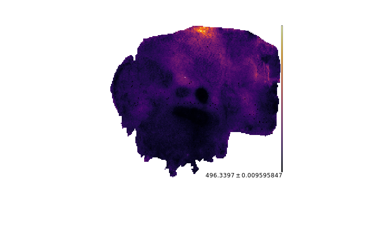

```r
#// output::ion image
s                 = MALDIquant::msiSlices(x = msData, center = queryMass,
                                          tolerance = (fwhmFun(queryMass) / 2.355) * 3)

if(sum(s, na.rm = T) == 0){
      par(mfrow = c(1, 1))
      #// image without masking
      spatstat::plot.owin(spwin,
                  main = paste0("No insances of m/z ", round(queryMass, 4), " were detected"),
                  ylim = rev(range(spwin$y)),
                  box = FALSE)
} else {

    MALDIquant::plotMsiSlice(x = s,
                             colRamp = colorRamp(viridis::viridis_pal(option = "inferno")(100)),
                             interpolate = F)

}
```

[output not shown]

```
20164 points were rejected as lying outside the specified window
```

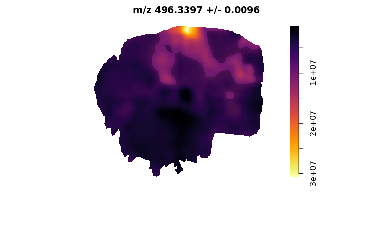

```r
#// output::molecular probability map
.uniqueMass       = as.numeric(spmat@Dimnames[[2]])


hits              = searchAnalyte(m = queryMass,
                                  fwhm = fwhmFun(queryMass),
                                  massAxis = .uniqueMass,
                                  spData = spmat,
                                  coords = MALDIquant::coordinates(msData))



#// check if hits is empty
if(nrow(hits) == 0)
{

  par(mfrow = c(1, 1))
  #// image without masking
  spatstat::plot.owin(spwin,
                  main = paste0("No insances of m/z ", round(queryMass, 4), " were detected"),
                  ylim = rev(range(spwin$y)),
                  box = FALSE)

} else {

  par(mfrow = c(1, 1))


  #// create the spatial point pattern
  hitsppp              = spatstat::ppp(x = hits$x,
                                       y = hits$y,
                                       window = spwin,
                                       marks = hits[ , -c(1, 2)])


  #// plotting

  probImg              = probMap(hitsppp, win = spwin, bwMethod = bwMethod)


  spatstat::plot.im(probImg$denspp,
                    main = paste0("m/z ", round(queryMass, 4), " +/- ", round((fwhmFun(queryMass) / 2.355) * 3, 4)),
                  col = spatstat::colourmap(viridis::viridis_pal(option = "inferno")(100), range = range(probImg$denspp, na.rm = T)),
                  ylim = rev(range(spwin$y)),
                  box = FALSE)
  spatstat::plot.im(probImg$nonHotspotMask, col = rgb(0,0,0,0.3), add = TRUE)





}
```

## Collective projection case - lipid classes

```r
if(detectionsExist) {

  tmpm                 = unique(searchList$lipidHits[[lipidClass]]$mass) # stores unique detected masses
tmpc                 = unique(searchList$lipidHits[[lipidClass]][c("mass", "confirmed", "modeAdduct")])

cat("\nConfirmed(metaspace) | Detected(in dataset) | Total(swisslipids) = ",
   length(which(tmpc$confirmed)),
   " | ",
   length(tmpm),
   " | ",
   nrow(searchList$swissList[[lipidClass]]) * 4, # because each entry has 4 different adducts
   "\n")
cat(" M+H  detected = ", length(which(tmpc$modeAdduct == "M+H") ),
   " | ",
   "M+H  confirmed = ", length(which(tmpc$modeAdduct == "M+H" & tmpc$confirmed)),
   "\n",
   "M-H  detected = ", length(which(tmpc$modeAdduct == "M-H") ),
   " | ",
   "M-H  confirmed = ", length(which(tmpc$modeAdduct == "M-H" & tmpc$confirmed)),
   "\n",
   "M+Na detected = ", length(which(tmpc$modeAdduct == "M+Na") ),
   " | ",
   "M+Na confirmed = ", length(which(tmpc$modeAdduct == "M+Na" & tmpc$confirmed == TRUE)),"\n",
   "M+K  detected = ", length(which(tmpc$modeAdduct == "M+K") ),
   " | ",
   "M+K  confirmed = ", length(which(tmpc$modeAdduct == "M+K" & tmpc$confirmed)),
   "\n",
   "\n\n\n")
}
```

```
Confirmed(metaspace) | Detected(in dataset) | Total(swisslipids) =  4  |  242  |  1776
 M+H  detected =  84  |  M+H  confirmed =  2
 M-H  detected =  0  |  M-H  confirmed =  0
 M+Na detected =  80  |  M+Na confirmed =  1
 M+K  detected =  78  |  M+K  confirmed =  1
```

plotting all detections

```
Attempting to generate 3464765 random points
Attempting to generate 3464765 random points1423261 points were rejected as lying outside the specified window
```

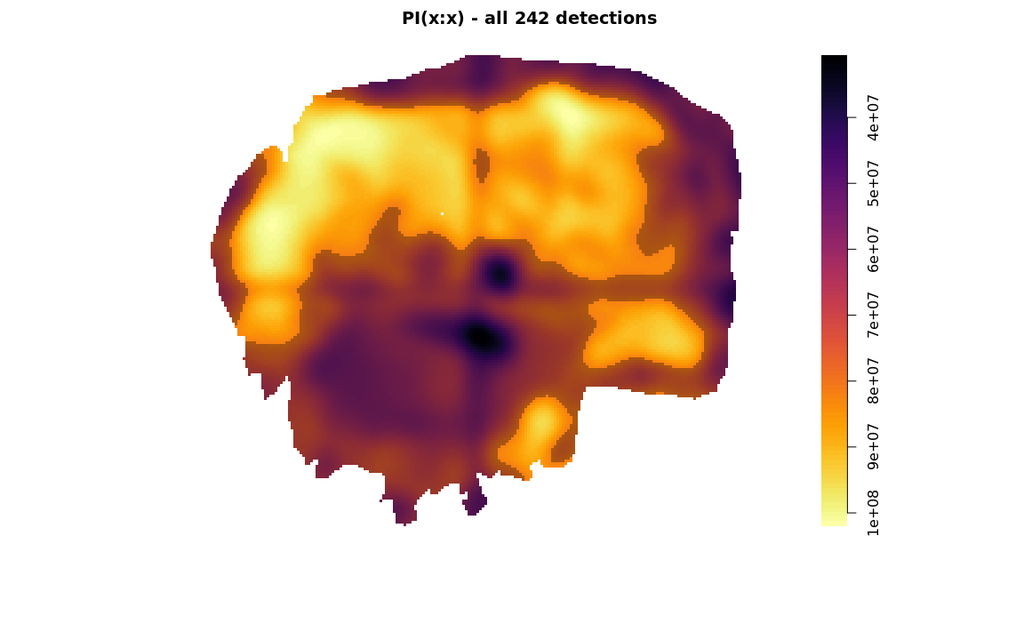

```r
# NOTE: would be better to have two bwMethod inputs; one for one analyte case (defaults to "iterative") and one for
# collective projection case (defaults to "scott").

if(detectionsExist) {




  probImg              = probMap(hitsppp, win = spwin, bwMethod = bwMethod)


  spatstat::plot.im(probImg$denspp,
                    main =  paste0(lipidClass, " - all ", length(tmpm), " detections"),
                  col = spatstat::colourmap(viridis::viridis_pal(option = "inferno")(100), range = range(probImg$denspp, na.rm = T)),
                  ylim = rev(range(spwin$y)),
                  box = FALSE)
  spatstat::plot.im(probImg$nonHotspotMask, col = rgb(0,0,0,0.3), add = TRUE)

}
```

plotting confirmed/verified detections

```r
 probImg              = probMap(subsetppp, win = spwin, bwMethod = bwMethod)
```

```
53075 points were rejected as lying outside the specified window
```

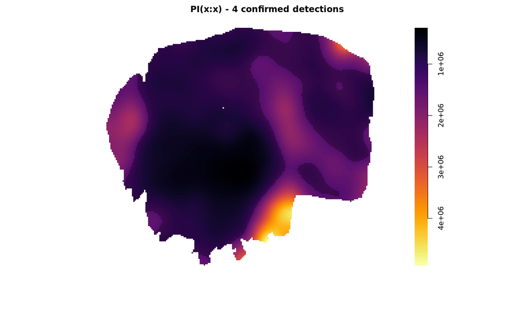

```r
  spatstat::plot.im(probImg$denspp,
                    main = paste0(lipidClass, " - ", length(which(tmpc$confirmed)), " confirmed detections"),
                  col = spatstat::colourmap(viridis::viridis_pal(option = "inferno")(100), range = range(probImg$denspp, na.rm = T)),
                  ylim = rev(range(spwin$y)),
                  box = FALSE)
  spatstat::plot.im(probImg$nonHotspotMask, col = rgb(0,0,0,0.3), add = TRUE)
```